# Problem: Maximum Likelihood Fit for the $\chi$ Distribution

## Maximum Likelihood -- definition

A random variable $x$ has some underlying probability distribution. The pdf $f(z)$ for this distribution usually depends on some parameters. If we call these parameters "$\theta$" we can write the pdf as $f(z,\theta)$ or $f(z\mid\theta)$.

There can be multiple parameters, so $\theta$ can be a vector, and it is perfectly fine to have $\theta = (\theta_1, \theta_2)$ for example.

Here $f(z\mid\theta)$ reflects the probability of observing a given value $z$ for the random variable $x$. Estimation is the process of finding values for the parameters $\theta$, given some observations $x_1$, ..., $x_n$.

In **Maximum Likelihood Estimation**, the idea is to find the value of $\theta$ that maximizes the likelihood of the observations $x_1$, ..., $x_n$ having been observed.

Although $f(z\mid\theta)$ reflects the probability of observing a given value $z$ for $x$, if we plug in the actually observed value $x_i$ then $f(x_i\mid\theta)$ is not really a "probability". R.A. Fisher called $f(x_i \mid \theta)$ the **likelihood** of observing $x_i$. We want to find the value of $\theta$ that maximizes the likelihood function

$$likelihood({x_1,...,x_n}) ~~=~~ \prod_{i=1}^n ~ f(x_i,\theta) .$$

The value of $\theta$ that maximizes this function is called the **maximum likelihood estimate (MLE)**.

## Example: Maximum Likelihood Fit for the Normal Distribution

Suppose $f$ is a **normal distribution** with parameters $\theta = (\mu,\sigma)$, so that:

$$ f(x, \theta) ~~=~~ \frac{1}{\sqrt{2\pi}\sigma} ~ \exp\left(-\frac{1}{2} \left(\frac{x - \mu}{\sigma}\right)^2 \right). $$

In this case the likelihood function is $$\mbox{likelihood}({x_1,...,x_n}) ~~=~~ \prod_i ~ f(x_i, \theta) ~~=~~ \left(\frac{1}{\sqrt{2\pi}\sigma}\right)^n ~ \exp\left(-\frac{1}{2} \sum_i \left(\frac{x_i - \mu}{\sigma}\right)^2 \right) . $$

The maximum likelihood estimate (value of $\theta$ that maximizes this function) clearly must minimize $\sum_i (x_i - \mu)^2$. By differentiating we can show that the minimum is obtained at $$\mu ~~=~~ \frac{1}{n} \sum_i x_i .$$

In other words, it turns out that the MLE is given by the usual formulas for $\mu$ and $\sigma$.

## Log-Likelihood

People often study **log-likelihood**, since it usually turns out to be easier to differentiate:

$$\log(~ \mbox{likelihood}({x_1,...,x_n}) ~ ) ~~=~~ \log(~ \prod_i f(x_i, \theta) ~ ) ~~=~~ \sum_i \log~ f(x_i, \theta). $$ Since the logarithm function $\log(t)$ is a **monotonic function** of $t$ (larger values of $t$ yield larger values of $\log(t)$), by maximizing log(likelihood) we will also maximize (likelihood).

In practice, since maximizing likelihood and log-likelihood are equivalent, people use log-likelihood.

# The Homework Problem: given an input set of data, find the MLE for the $\chi$ distribution

Given input values $x_1$, ..., $x_n$. we want to find the MLE parameters $\theta = (\nu)$, where $\nu$ is the degrees of freedom. In other words, here $\theta$ is a single parameter "nu".

However, we cannot use *fitdistr* for this, since *fitdistr* does not cover the $\chi$ distribution. (It does cover the $\chi^2$ distribution, but not its less-well-known friend $\chi$).

$\chi$ is the distribution of $$ \sqrt{\sum_{i=1}^n \left(\frac{X_i-\mu_i}{\sigma_i}\right)^2} $$ where $\chi^2$ is the distribution of $$ \sum_{i=1}^n \left(\frac{X_i-\mu_i}{\sigma_i}\right)^2. $$

```python
%load_ext rmagic
import rpy2 as Rpy
```

### First, let's implement the chi distribution pdf in R.

The $\chi$ distribution is described in en.wikipedia.org/wiki/Chi_distribution.

```python
%%R

dchi = function(x,nu) dchisq(x^2, nu) * (2*x)

# this gives us an implementation of the pdf
```

For fun, let's plot some values of the $\chi$ distribution:

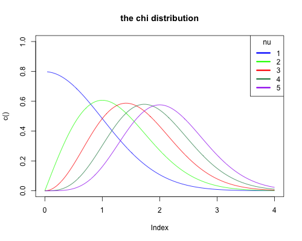

```python
%%R -w 500 -h 400

plot( c(), c(), type="n", main="the chi distribution",
     xlim=c(0,4), ylim=c(0,1) )  # start the basic plot

#  add a curve for each chi distribution parameter value:
curve( dchi(x,1), col="blue", add=TRUE )
curve( dchi(x,2), col="green", add=TRUE )
curve( dchi(x,3), col="red", add=TRUE )
curve( dchi(x,4), col="seagreen", add=TRUE )
curve( dchi(x,5), col="purple", add=TRUE )

legend( "topright", paste(c(1,2,3,4,5)), title="nu",
         col=c("blue","green","red","seagreen","purple"), lwd=3)

# this is a copy of the Wikipedia plot
```

# The actual homework problem

You are given an $n \times p$ table as input.

Each column of this table is a "dataset" $x_1$, ..., $x_n$.

Your job is to find the MLE for nu using the $\chi$ distribution. For this problem you can assume that the MLE is an integer, so your program can round any non-integer value to an integer.

Your program should do this for each column in the table, and print the result as a sequence of lines; each line should have the characters "chi *n*", where *n* is an integer.

For example, if we were given a table with values for the five values of nu above, the output would be:

```
chi 1
chi 2
chi 3
chi 4
chi 5
```

## The Log-Likelihood Function

```python
%%R

Dataset = rchisq(1000, 4, 2)   # a sample dataset

log_likelihood = function(theta) sum( log(dchi(Dataset, theta)) )
```

```python
%%R

# learn about the optimizer in R

?optim
```

```python
%%R
initial_value_for_nu = 2
negative_log_likelihood = function(theta) -log_likelihood(theta)

# optim always _minimizes_ a function,
#   so to find the MLE we minimize the negative log likelihood:

output_of_optimization =
  optim( initial_value_for_nu, negative_log_likelihood, method="BFGS" )

print(output_of_optimization)
```

```
$par
[1] 22.41875

$value
[1] 15722.69

$counts
function gradient
      34       NA

$convergence
[1] 0

$message
NULL
```

```python
%%R

minimum_negative_log_likelihood_value = output_of_optimization$value

MLE_for_nu = round( output_of_optimization$par )

print(MLE_for_nu)
```

```
[1] 22
```

```python
%%R

# Finally:  print out the estimate for nu in the format required:

cat(sprintf("chi %d\n", MLE_for_nu ))
```

```
chi 22
```

## That's it! Now write a program that does this for any input dataset...

Your R script should accept an input file from standard input. You can reuse the following line of code from problem A.  
Table = data.matrix(read.csv( file='stdin', header=TRUE ))  
Please note that you need to format your output correctly. Suppose we use underscore '_' to represent space, then the following output:  
chi 22  
is actually:  
chi_22\n  
If you see "Presentation Error" as the feedback from the online judge, you might not have dealt with the space or end-of-line correctly.

# Optional Challenge: implement the chi distribution cdf and icdf

***Note: Please do not submit the codes for this optional challenge to the online judge.

The cdf of the $\chi$ distribution can be found at en.wikipedia.org/wiki/Chi_distribution.

```python
%%R

dchi = function(x,nu) dchi(x^2, nu) * (2*x)  # implementation of the pdf
pchi = function(x,nu) 0 # how can we implement the cdf?
qchi = function(x,nu) 0 # how can we implement the icdf?
```

# Optional Challenge: implement a random generator for the chi distribution

***Note: Please do not submit the codes for this optional challenge to the online judge.

```python
%%R

rchi = function(n,nu) qchi(runif(n),nu)  # random chi values = transformed random uniform values

# we can implement a random generator for any distribution using its icdf
```